# NI_Trapezoidal_rule

```python
import numpy as np
import pandas as pd

# Visualisation libraries

## Text
from colorama import Fore, Back, Style
from IPython.display import Image, display, Markdown, Latex, clear_output

## plotly
from plotly.offline import init_notebook_mode, iplot
import plotly.graph_objs as go
import plotly.offline as py
from plotly.validators.scatter.marker import SymbolValidator
from plotly.subplots import make_subplots

## seaborn
import seaborn as sns

## matplotlib
import matplotlib.pyplot as plt
from matplotlib.patches import Ellipse, Polygon
from matplotlib.font_manager import FontProperties
plt.style.use('seaborn-white')
plt.rcParams['axes.labelsize'] = 14
plt.rcParams['xtick.labelsize'] = 12
plt.rcParams['ytick.labelsize'] = 12
plt.rcParams['text.color'] = 'k'
%matplotlib inline

import warnings
warnings.filterwarnings("ignore")
```

[Home](https://hatefdastour.github.io/) / [Numerical Integration](https://hatefdastour.github.io/notes/Numerical_Analysis/)

## Numerical Integration

- [**Trapezoidal rule**](https://hatefdastour.github.io/notes/Numerical_Analysis/NI_Trapezoidal_rule.html)
- [**Simpsons_rule**](https://hatefdastour.github.io/notes/Numerical_Analysis/NI_Simpsons_rule.html)
- [**Midpoint rule**](https://hatefdastour.github.io/notes/Numerical_Analysis/NI_Midpoint_rule.html)
- [**Gaussian quadrature**](https://hatefdastour.github.io/notes/Numerical_Analysis/NI_Gaussian_quadrature.html)

**Numerical Integration**

In many practical applications, an approximation of the integral of some functions is needed. In many cases, the definite integral of some functions is not possible as the antiderivatives of these functions are not easy to obtain.

In the methods of quadrature, a set of distinct nodes \${x_0, \ldots, x_n\}$ from an interval [a, b] is selected, and then the integrate is approximated utilizing the Lagrange interpolating polynomial [2]:

\begin{align} L(x)=\sum _{j=0}^{n}y_{j}L_{j}(x) \end{align}

Moreover, letting \begin{align} a_{i}=\int_{a}^{b}L_{j}(x)dx \end{align} the quadrature formula is defined as follows, \begin{align} \int_{a}^{b}f(x)\,dx \approx \sum _{j=0}^{n}a_{i}f(x_{i}). \end{align}

The error of these approximation is given by [2] \begin{align} \text{Error }(f) = \frac{1}{(n+1)!} \int_{a}^{b} \prod_{i=1}^{n} (x- x_{i}) f^{n+1} (\xi(x)) \,dx \end{align} where $\xi(x) \in [a, b]$.

# Trapezoidal rule

Let $\{x_{n}\}$ be a partition of $[a,b]$ such that $a=x_{0}<x_{1}<\cdots <x_{N-1}<x_{N}=b$ and $\Delta x_{n}$ be the length of the $k$-th subinterval (that is,$\Delta x_{n}=x_{n}-x_{n-1}$), then

\begin{align} \int _{a}^{b}f(x)\,dx\approx \frac {1}{2}\sum _{n=1}^{N}\left(f(x_{n-1})+f(x_{n})\right)\Delta x_{n}. \end{align}

Now if, these points are equally distanced. i.e. $\Delta x_{n}= h>0$ for $n\in \{0,1,\ldots,N\}$ , \begin{align} \int _{a}^{b}f(x)\,dx\approx \frac {h}{2}\sum _{n=1}^{N} \left(f(x_{n-1})+f(x_{n})\right) \end{align}

Furthermore, we can implement this algorithm in Python.

```python
def Trapz(f, a, b, N):
    '''
    f : single variable function f
    a , b : Interval of integration [a,b]
    N : Number of subintervals of [a,b]
    '''

    # discretizing [a,b] into N subintervals
    x = np.linspace(a, b, N+1)
    # discretizing function f on [a,b]
    fn = f(x)
     # fn[1:]: Right endpoints
     # fn[:-1]: Left endpoints
    # the increment \delta x
    h = (b - a)/N
    ### Trapezoidal rule
    T = (h/2) * np.sum(fn[1:] + fn[:-1])
    return T

def TrapzPlots(f, a, b, N, ax = False, CL = 'Tomato', EC = 'Blue', Font = False):
    if not ax:
        fig, ax = plt.subplots(nrows=1, ncols=1, figsize=(8, 6))
    x = np.linspace(a, b, N+1)
    y = f(x)

    X = np.linspace(a, b, (N**2)+1)
    Y = f(X)
    _ = ax.plot(X,Y)
    for i in range(N):
        ax.fill([x[i], x[i], x[i+1], x[i+1]], [0, f(x[i]), f(x[i+1]), 0], facecolor = CL,
                edgecolor= EC,alpha=0.3, hatch='', linewidth=1.5)
    if Font:
        _ = ax.set_title('Trapezoid Rule (N = %i)' % N, fontproperties = Font, fontsize = 14)
    else:
        _ = ax.set_title('Trapezoid Rule (N = %i)' % N, fontsize = 14)
    _ = ax.set_xlim([min(x),max(x)])
    _ = ax.set_ylim([0,max(y)])
```

**Example**: Apply the Trapezoid rule on \begin{align} \int_{0}^{\pi/4} \cos^2(x)\, dx. \end{align}

We have,

$$\frac {h}{2}\sum _{n=1}^{10} \left(f(x_{n-1})+f(x_{n})\right) = 6.4218e-01$$

$$\frac {h}{2}\sum _{n=1}^{20} \left(f(x_{n-1})+f(x_{n})\right) = 6.4257e-01$$

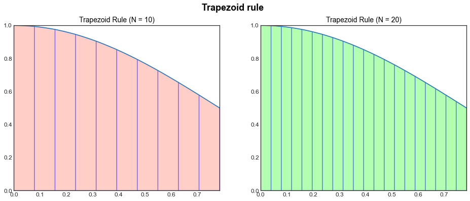

```python
f = lambda x : np.cos(x)**2
a =0
b= np.pi/4
N = [10, 20]
#
fig, ax = plt.subplots(nrows=1, ncols=len(N), figsize=(16, 6))
ax = ax.ravel()
Colors = ['Tomato', 'Lime']
font = FontProperties()
font.set_weight('bold')
_ = fig.suptitle('Trapezoid rule', fontproperties=font, fontsize = 18)
for i in range(len(ax)):
    TrapzPlots(f= f, a = a, b= b, N = N[i], ax = ax[i], CL = Colors[i])
    Int_trapz = Trapz(f= f, a = a, b= b, N = N[i])
    display(Latex('''$$\\frac {h}{2}\\sum _{n=1}^{%i} \\left(f(x_{n-1})+f(x_{n})\\right) = %.4e$$''' % (N[i], Int_trapz)))
    del Int_trapz
del i
```

## Error Estimation

\begin{align} E_{h} = \left|\int _{a}^{b}f(x)\,dx - \frac {h}{2}\sum _{n=1}^{N} \left(f(x_{n-1})+f(x_{n})\right)\right| = \frac {(b-a)}{12}h^{2} f''(\xi), \qquad \text{for some }\xi \in [a, b]. \end{align}

**Example**: Consider evaluating \begin{align} \int_{0}^{2} \frac{1}{1+x}\, dx. \end{align} We know that $$\int_{0}^{2} \frac{1}{1+x}\, dx = \ln(x+1) \Big|_{0}^{2} = \ln(3).$$

Let's assume that we are interested in evaluing this integral using the Trapezoid rule. For instance, to ensure that the error is less than $5 \times 10^{-6}$, we have,

\begin{align} f(x) = \frac{1}{x+1} \quad \Rightarrow \quad f'(x) = -\frac{1}{(x + 1)^2} \quad \Rightarrow \quad f''(x) = \frac{2}{(x + 1)^3} . \end{align}

```python
E = 5e-6
f = lambda x : 1/(x+1)
f2 =  lambda x : 2/((x+1)**3)
Exact = np.log(3)
a =0
b= 2
x = np.linspace(a, b)
M = max(abs(f2(x)))
display(Latex('''$$\\max_{%.2f \leq x \leq %.2f}|f''(x)| = %.2f$$''' % (a, b, M)))
```

$$\max_{0.00 \leq x \leq 2.00}|f''(x)| = 2.00$$

Thus, it follows from solving the following inequality that

```python
display(Latex('''$$\\frac{b -a}{12}h^2 \\max_{a \leq x \leq b}|f''(x)| \leq %.2e$$''' % E))
h = float('%.0e' % (np.sqrt(E/(((b-a)/12)*M))))
display(Latex('''$$h = %.2e$$''' % h))
N = int(np.ceil((b-a)/h))
display(Latex('''$$N = %i$$''' % N))
```

$$\frac{b -a}{12}h^2 \max_{a \leq x \leq b}|f''(x)| \leq 5.00e-06$$

$$h = 4.00e-03$$

$$N = 500$$

Therefore,

```python
T = Trapz(f, a, b, N)
display(Latex('''$$E_{h} = %.2e$$''' % np.abs(Exact - T)))
```

$$E_{h} = 1.19e-06$$

Moreover, to see the order of accuracy of this method, we can consider the following test.

```python
def Figs(Mtd, h = [2**(-i) for i in range(3, 10)],
          f =f, a = a, b =b, Exact = Exact,
          yLim = [1.9, 2.1], size = [550, 980], Title = False):
    Cols = ['h', 'N', 'Eh']
    Table = pd.DataFrame(np.zeros([len(h), len(Cols)], dtype = float), columns=Cols)
    Table['h'] = h
    Table['N'] = ((b-a)/Table['h']).astype(int)

    for i in range(Table.shape[0]):
        Table['Eh'][i] = np.abs(Mtd(f, a, b, Table['N'][i]) - Exact)

    fig = make_subplots(rows=1, cols=2, horizontal_spacing = 0.02, column_widths=[0.6, 0.4],
                        specs=[[{"type": "scatter"},{"type": "table"}]])
    s = np.log2(Table['Eh'].values[:-1]/Table['Eh'].values[1:])
    fig.add_trace(go.Scatter(x = np.arange(1, len(s)+1), y = s, mode='markers',
                             marker_symbol='circle',
                             marker_line_color="midnightblue", marker_color="lightskyblue",
                             marker_line_width=2, marker_size=10), row=1, col=1)
    fig.update_xaxes(showline=True, linewidth=1, linecolor='Lightgray', mirror=True,
                     dtick=1,
    #                  zeroline=True, zerolinewidth=1, zerolinecolor='Black',
                     showgrid=True, gridwidth=1, gridcolor='Lightgray', title_text = '$h_i$',
                     range= [0.8, len(s)+.2], row=1, col=1)
    fig.update_yaxes(showline=True, linewidth=1, linecolor='Lightgray', mirror=True,
                     zeroline=True, zerolinewidth=1, zerolinecolor='Black',
                     showgrid=True, gridwidth=1, gridcolor='Lightgray',
                     title_text = '$\\log_{2} \\left( \\frac{E_{h_{i}}}{E_{h_{i-1}} }\\right)$', range= yLim, row=1, col=1)
    fig.update_layout(plot_bgcolor= 'white', height= size[0] , width= size[1], showlegend=False)

    T = Table.copy()
    T[['h','Eh']] = T[['h','Eh']].applymap(lambda x: '%.4e' % x)
    Temp = []
    for i in T.columns:
        Temp.append(T.loc[:,i].values)

    fig.add_trace(go.Table(header=dict(values = list(Table.columns), line_color='darkslategray',
                                   fill_color='Navy', align=['center','center'],
                                   font=dict(color='white', size=12), height=25), columnwidth = [0.4, 0.2, 0.4],
                       cells=dict(values=Temp, line_color='darkslategray', fill=dict(color= ['white', 'white', 'Lavender']),
                                  align=['center', 'center'], font_size=12, height=20)), 1, 2)
    del Temp, T
    if Title:
        fig.update_layout(title={'text': '<b>' + 'Order of accuracy (%s)' % Title + '<b>', 'x':0.5,
                                 'y':0.90, 'xanchor': 'center', 'yanchor': 'top'})
    else:
        fig.update_layout(title={'text': '<b>' + 'Order of accuracy' + '<b>', 'x':0.5,
                                 'y':0.90, 'xanchor': 'center', 'yanchor': 'top'})
    fig.show()
```

```python
Figs(Mtd = Trapz, Title = """Trapezoidal rule""")
```

[interactive chart not shown]

# References

1. Allaire, Grégoire, et al. Numerical linear algebra. Vol. 55. New York: Springer, 2008.
2. Burden, Richard L., and J. Douglas Faires. "Numerical analysis 8th ed." Thomson Brooks/Cole (2005).
3. Atkinson, Kendall E. An introduction to numerical analysis. John wiley & sons, 2008.
4. Khoury, Richard, and Douglas Wilhelm Harder. Numerical methods and modelling for engineering. Springer, 2016.
5. Zarowski, Christopher J. An introduction to numerical analysis for electrical and computer engineers. John Wiley & Sons, 2004.
6. [Numerical integration Wikipedia page](https://en.wikipedia.org/wiki/Numerical_integration)
7. [Trapezoidal rule Wikipedia page](https://en.wikipedia.org/wiki/Trapezoidal_rule)